# Shyshark Distribution

Emma Swanepoel

2024-02-23

This is a GIS on shyshark distribution around southern Africa. Shysharks are endemic benthic species found around the southern African coastline. There are four species (*Haploblepharus edwardsii*, *H. pictus*, *H. fuscus*, and *H. kistnasamyi*). As the latter two are quite criptic, this visual representation will focus on the observations made of Happy Eddies or Puffadder shysharks (*H. edwardsii*) and Dark shysharks (*H. pictus*).

To run the code you will need the packages tidyverse, sp, sf, raster, lwgeom, terra, stars, exactextractr, hrbrthemes,cowplot, rinat, prettymapr, ggspatial, leaflet, mapview, htmltools, leafpop, rnaturalearth, and rnaturalearthdata.

First we need to read in some shyshark data from iNaturalist.

```r
puffyshark <- get_inat_obs(taxon_name = "Haploblepharus edwardsii", maxresults = 600)
darkshark <- get_inat_obs(taxon_name = "Haploblepharus pictus", maxresults = 600)
```

Then we need to filter the observations to include only research grade observations and observations with a positional accuracy less than 100m, we also exclude faulty observations made in the Northern Hemisphere and all data with NA latitude values.

```r
puffyshark <- puffyshark %>% filter(positional_accuracy < 100 & latitude <0 & !is.na(latitude) & quality_grade == "research")
darkshark <- darkshark %>% filter(positional_accuracy < 100 & latitude <0 & !is.na(latitude) & quality_grade == "research")
```

In order to actually plot these data we need to make the dataframes spatial objects of the class “sf”.

```r
puffyshark <- st_as_sf(puffyshark, coords = c("longitude", "latitude"), crs = 4326)
darkshark <- st_as_sf(darkshark, coords = c("longitude", "latitude"), crs = 4326)
```

Very important!! We need to check the dataframes to make sure they’ve been transformed into spatial objects and check that the coordinate reference systems (CRS) are the same.

```r
class(puffyshark)
```

```
## [1] "sf"         "data.frame"
```

```r
class(darkshark)
```

```
## [1] "sf"         "data.frame"
```

```r
st_crs(puffyshark)
```

```
## Coordinate Reference System:
##   User input: EPSG:4326
##   wkt:
## GEOGCRS["WGS 84",
##     ENSEMBLE["World Geodetic System 1984 ensemble",
##         MEMBER["World Geodetic System 1984 (Transit)"],
##         MEMBER["World Geodetic System 1984 (G730)"],
##         MEMBER["World Geodetic System 1984 (G873)"],
##         MEMBER["World Geodetic System 1984 (G1150)"],
##         MEMBER["World Geodetic System 1984 (G1674)"],
##         MEMBER["World Geodetic System 1984 (G1762)"],
##         MEMBER["World Geodetic System 1984 (G2139)"],
##         ELLIPSOID["WGS 84",6378137,298.257223563,
##             LENGTHUNIT["metre",1]],
##         ENSEMBLEACCURACY[2.0]],
##     PRIMEM["Greenwich",0,
##         ANGLEUNIT["degree",0.0174532925199433]],
##     CS[ellipsoidal,2],
##         AXIS["geodetic latitude (Lat)",north,
##             ORDER[1],
##             ANGLEUNIT["degree",0.0174532925199433]],
##         AXIS["geodetic longitude (Lon)",east,
##             ORDER[2],
##             ANGLEUNIT["degree",0.0174532925199433]],
##     USAGE[
##         SCOPE["Horizontal component of 3D system."],
##         AREA["World."],
##         BBOX[-90,-180,90,180]],
##     ID["EPSG",4326]]
```

```r
st_crs(darkshark)
```

```
## Coordinate Reference System:
##   User input: EPSG:4326
##   wkt:
## GEOGCRS["WGS 84",
##     ENSEMBLE["World Geodetic System 1984 ensemble",
##         MEMBER["World Geodetic System 1984 (Transit)"],
##         MEMBER["World Geodetic System 1984 (G730)"],
##         MEMBER["World Geodetic System 1984 (G873)"],
##         MEMBER["World Geodetic System 1984 (G1150)"],
##         MEMBER["World Geodetic System 1984 (G1674)"],
##         MEMBER["World Geodetic System 1984 (G1762)"],
##         MEMBER["World Geodetic System 1984 (G2139)"],
##         ELLIPSOID["WGS 84",6378137,298.257223563,
##             LENGTHUNIT["metre",1]],
##         ENSEMBLEACCURACY[2.0]],
##     PRIMEM["Greenwich",0,
##         ANGLEUNIT["degree",0.0174532925199433]],
##     CS[ellipsoidal,2],
##         AXIS["geodetic latitude (Lat)",north,
##             ORDER[1],
##             ANGLEUNIT["degree",0.0174532925199433]],
##         AXIS["geodetic longitude (Lon)",east,
##             ORDER[2],
##             ANGLEUNIT["degree",0.0174532925199433]],
##     USAGE[
##         SCOPE["Horizontal component of 3D system."],
##         AREA["World."],
##         BBOX[-90,-180,90,180]],
##     ID["EPSG",4326]]
```

Nice!! All systems go!

Let’s do some more filtering! We want to exclude observations of **sharks** made **on land** *(shoutout to ChatGPT for the help)*. We start by creating a dataframe for the land surface.

```r
world_land <- ne_countries(scale = "medium", returnclass = "sf", country = "south africa")
```

Now we want to spatially join this df to ID the observations on land for the sharks and create new dataframes *without those observations*.

```r
landsharks_ps <- st_join(puffyshark, world_land, join = st_disjoint) %>%
  filter(!is.na(iso_a2))
# Exclude land shark observations from puffyshark
oceanshark_ps <- puffyshark[puffyshark$geometry %in% landsharks_ps$geometry,]
# Spatial join to ID observations on land for darksharks
landsharks_ds <- st_join(darkshark, world_land, join = st_disjoint) %>%
  filter(!is.na(iso_a2))
# Exclude land shark observations from darkshark
oceanshark_ds <- darkshark[darkshark$geometry %in% landsharks_ds$geometry,]
```

Let’s see if all that worked by plotting these data.

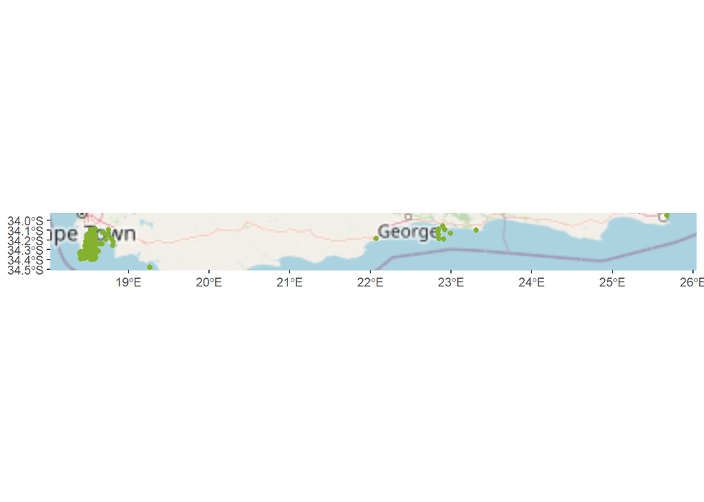

```r
ggplot() +
  annotation_map_tile(type = "osm", progress = "none") +
  geom_sf(data = oceanshark_ps, color = "#85B22C")
```

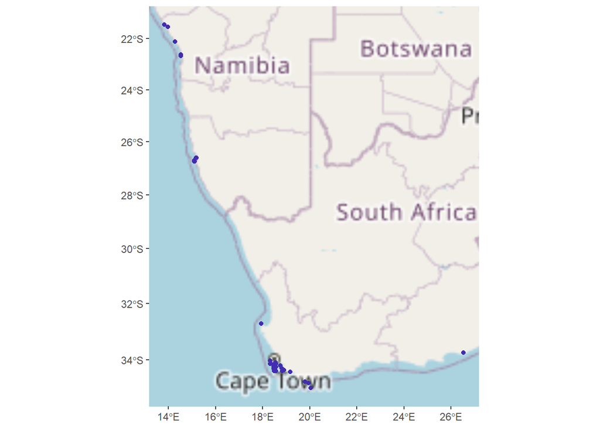

```r
ggplot() +
  annotation_map_tile(type = "osm", progress = "none") +
  geom_sf(data = oceanshark_ds, color = "#422CB2")
```

Hmm. It would be more helpful if both species were on one map…

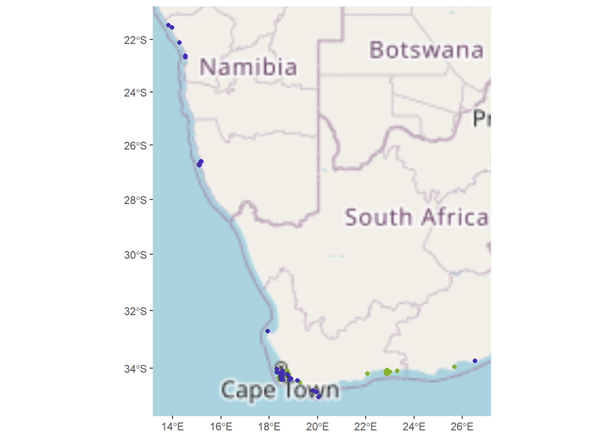

```r
ggplot() +
  annotation_map_tile(type = "osm", progress = "none") +
  geom_sf(data = oceanshark_ps, color = "#85B22C") +
  geom_sf(data = oceanshark_ds, color = "#422CB2")
```

That’s better!

Now the fun part - creating interacive maps with both species!

```r
leaflet() %>%
  addTiles(group = "Default") %>%
  addCircleMarkers(data = oceanshark_ps,
                   group = "Haploblepharus edwardsii",
                   radius = 1,
                   color = "#85B22C")%>%
  addCircleMarkers(data = oceanshark_ds,
                   group = "Haploblepharus pictus",
                   radius = 1,
                   color = "#422CB2")%>%
  addLegend(position = "topright", colors = c("#85B22C", "#422CB2"), labels = c("Puffadder shyshark", "Dark shyshark"))
```

[interactive chart not shown]

Next we want to create an interactive map with mapview and create popups for each data point with links to the iNaturalist observations. So - first thing’s first - let’s make the links possible.

```r
loceanshark_ps <- oceanshark_ps %>%
  mutate(click_url = paste("<b><a href='", url, "'>Link to iNat observation</a></b>"))
loceanshark_ds <- oceanshark_ds %>%
  mutate(click_url = paste("<b><a href='", url, "'>Link to iNat observation</a></b>"))
```

Finally! Let’s create an interactive map with links to each point’s iNaturalist observation!

```r
mapview(oceanshark_ps, col.regions = "#85B22C", layer.name = "Puffadder shyshark", legend = TRUE,
        popup =
          popupTable(loceanshark_ps,
                     zcol = c("user_login", "click_url", "id"))) +
mapview(oceanshark_ds, col.regions = "#422CB2", layer.name = "Dark shyshark", legend = TRUE,
        popup =
          popupTable(loceanshark_ds,
                     zcol = c("user_login", "click_url", "id")))
```

[interactive chart not shown]

This RMarkdown was made with lots of crying and swearing by the author but hopefully it will be appreciated